# Data-580 Lab 4

Dhun Sheth

2023-10-05

## Question 1

### Part A

```r
m <- 10000; n <- 100; sigma <- 5
M <- matrix(rnorm(m*n, mean = 3, sd = sigma), nrow=n)
xbar <- apply(M, 2,mean)

estimate <- mean(xbar>4.5)
print(estimate)
```

```
## [1] 0.001
```

```r
theory <- 1-pnorm((4.5-3)/sqrt(25/n))
print(theory)
```

```
## [1] 0.001349898
```

### Part B

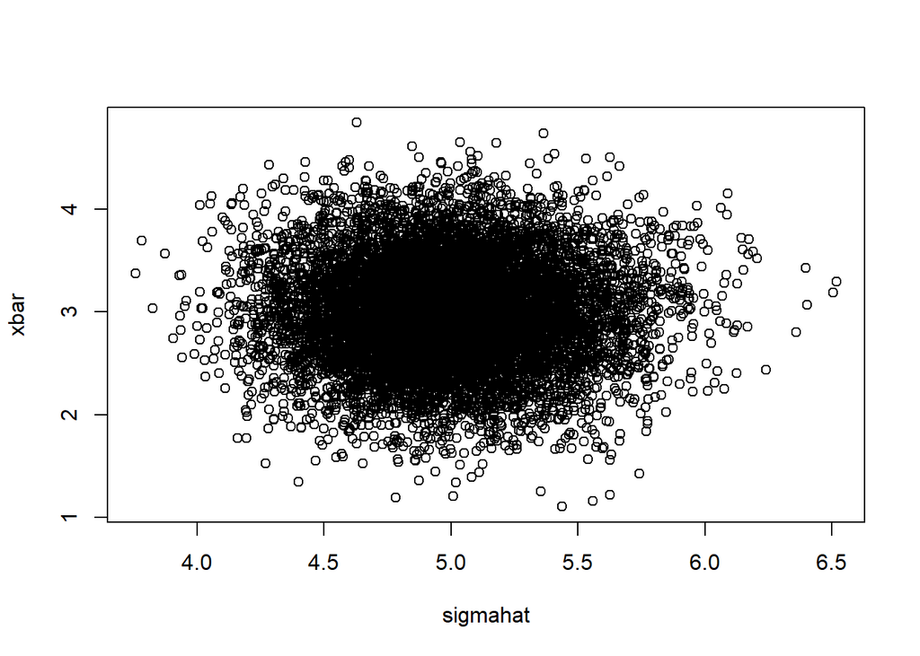

```r
sigmahat=apply(M, 2,sd)
plot(xbar ~ sigmahat)
```

### Part C

```r
left_side = mean(xbar/sigmahat)
right_side = mean(xbar)*mean(1/sigmahat)
print(left_side)
```

```
## [1] 0.6037602
```

```r
print(right_side)
```

```
## [1] 0.6037658
```

Based on values
$$E[X_n/S_n]=E[x_n]*E[1/S_n]$$

## Question 2

```r
phi1 <- 0.2
Z <- arima.sim(100, model = list(ar = phi1), sd = 1)
```

### Part B

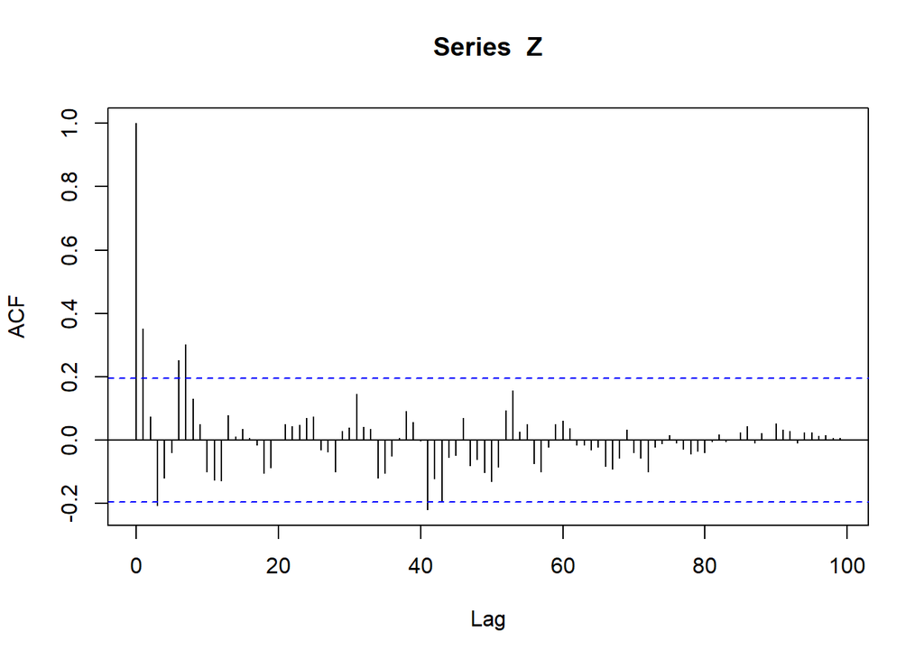

```r
acf(Z, lag=100)
```

### Part C

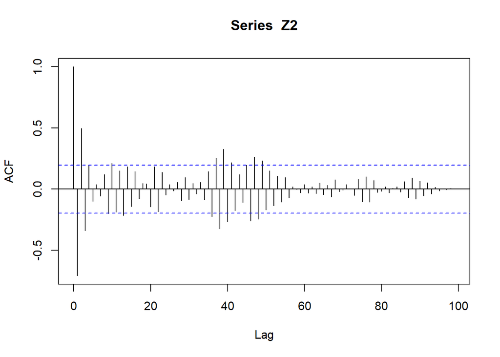

```r
phi2 <- -0.8
Z2 <- arima.sim(100, model = list(ar = phi2), sd = 1)
acf(Z2, lag=100)
```

Comparing the ACF plots with parameter 0.2 vs. -0.8, the -0.8 parameter starts with much higher correlation during the initial lags but both ACF plots oscillate and decrease by lag 100. Parameter 0.2 oscillates slower than parameter -0.8.

## Question 3

### Part A

```r
set.seed(1333)

x <- seq(0, 1, length=100)
eps_i <- rnorm(100, sd = 1)
y0 <- 2 + 3*x + eps_i

set.seed(1333)
eps_ii <- arima.sim(100, model = list(ar = 0.8), sd = 1)
y1 <- 2 + 3*x + eps_ii
```

### Part B

```r
y0.lm <- lm(y0 ~ x)
y1.lm <- lm(y1 ~ x)

print(coef(y0.lm))
```

```
## (Intercept)           x
##    2.078381    2.877188
```

```r
print(coef(y1.lm))
```

```
## (Intercept)           x
##    2.052800    3.417216
```

$$Case 1: Y = 2.877x + 2.078$$
$$Case 2: Y = 3.417x + 2.053$$

### Part C

```r
x=0.8
Y0 <- 2.877*x + 2.078
Y1 <- 3.417*x + 2.053

true_exp <- 2+3*x

print(Y0)
```

```
## [1] 4.3796
```

```r
print(Y1)
```

```
## [1] 4.7866
```

```r
print(true_exp)
```

```
## [1] 4.4
```

Case 1 is closer to the true expected value.

### Part D

The noise term has dependency in case 2, as seen from the ACF plot in question 2 for AR(1), and based on the regression results, having a noise term with dependency leads to a less accurate regression model, as we compare the regression estimates from case 1 (no dependency in noise term) and case 2 (dependency in noise term) to the true expected value.